# R Notebook

The Dogs vs. Cats dataset that you’ll use isn’t packaged with Keras. It was made available by Kaggle as part of a computer-vision competition in late 2013, back when convnets weren’t mainstream. You can download the original dataset from www.kaggle.com/c/dogs-vs-cats/data

Copying images to train, validation, and test directories ***

```r
original_dataset_dir <- "~/datasets/catsndogs/train"

base_dir <- "~/Downloads/cats_and_dogs_small"
dir.create(base_dir)
```

```
'/Users/raul.reguillo/Downloads/cats_and_dogs_small' ya existe
```

```r
train_dir <- file.path(base_dir, "train")
dir.create(train_dir)
```

```
'/Users/raul.reguillo/Downloads/cats_and_dogs_small/train' ya existe
```

```r
validation_dir <- file.path(base_dir, "validation")
dir.create(validation_dir)
```

```
'/Users/raul.reguillo/Downloads/cats_and_dogs_small/validation' ya existe
```

```r
test_dir <- file.path(base_dir, "test")
dir.create(test_dir)
```

```
'/Users/raul.reguillo/Downloads/cats_and_dogs_small/test' ya existe
```

```r
train_cats_dir <- file.path(train_dir, "cats")
dir.create(train_cats_dir)
```

```
'/Users/raul.reguillo/Downloads/cats_and_dogs_small/train/cats' ya existe
```

```r
train_dogs_dir <- file.path(train_dir, "dogs")
dir.create(train_dogs_dir)
```

```
'/Users/raul.reguillo/Downloads/cats_and_dogs_small/train/dogs' ya existe
```

```r
validation_cats_dir <- file.path(validation_dir, "cats")
dir.create(validation_cats_dir)
```

```
'/Users/raul.reguillo/Downloads/cats_and_dogs_small/validation/cats' ya existe
```

```r
validation_dogs_dir <- file.path(validation_dir, "dogs")
dir.create(validation_dogs_dir)
```

```
'/Users/raul.reguillo/Downloads/cats_and_dogs_small/validation/dogs' ya existe
```

```r
test_cats_dir <- file.path(test_dir, "cats")
dir.create(test_cats_dir)
```

```
'/Users/raul.reguillo/Downloads/cats_and_dogs_small/test/cats' ya existe
```

```r
test_dogs_dir <- file.path(test_dir, "dogs")
dir.create(test_dogs_dir)
```

```
'/Users/raul.reguillo/Downloads/cats_and_dogs_small/test/dogs' ya existe
```

```r
fnames <- paste0("cat.", 1:1000, ".jpg")
file.copy(file.path(original_dataset_dir, fnames),file.path(train_cats_dir))
```

[output not shown]

[output cut: 38 more lines]

```r
fnames <- paste0("cat.", 1001:1500, ".jpg")
file.copy(file.path(original_dataset_dir, fnames),
file.path(validation_cats_dir))
```

[output not shown]

```r
fnames <- paste0("cat.", 1501:2000, ".jpg")
file.copy(file.path(original_dataset_dir, fnames),
file.path(test_cats_dir))
```

[output not shown]

```r
fnames <- paste0("dog.", 1:1000, ".jpg")
file.copy(file.path(original_dataset_dir, fnames),
file.path(train_dogs_dir))
```

[output not shown]

[output cut: 38 more lines]

```r
fnames <- paste0("dog.", 1001:1500, ".jpg")
file.copy(file.path(original_dataset_dir, fnames),
file.path(validation_dogs_dir))
```

[output not shown]

```r
fnames <- paste0("dog.", 1501:2000, ".jpg")
file.copy(file.path(original_dataset_dir, fnames),
file.path(test_dogs_dir))
```

[output not shown]

```r
# As a sanity check, let’s count how many pictures are in each training split (train/validation/test):

cat("total training cat images:", length(list.files(train_cats_dir)), "\n")
```

```
total training cat images: 1000
```

```r
cat("total training dog images:", length(list.files(train_dogs_dir)), "\n")
```

```
total training dog images: 1000
```

```r
cat("total validation cat images:", length(list.files(validation_cats_dir)), "\n")
```

```
total validation cat images: 500
```

```r
cat("total validation dog images:", length(list.files(validation_dogs_dir)), "\n")
```

```
total validation dog images: 500
```

```r
cat("total test cat images:", length(list.files(test_cats_dir)), "\n")
```

```
total test cat images: 500
```

```r
cat("total test dog images:", length(list.files(test_dogs_dir)), "\n")
```

```
total test dog images: 500
```

Instantiating a small convnet for cats vs. dogs classification ***

```r
library(keras)
model <- keras_model_sequential() %>%
layer_conv_2d(filters = 32, kernel_size = c(3, 3), activation = "relu",
                input_shape = c(150, 150, 3)) %>%
  layer_max_pooling_2d(pool_size = c(2, 2)) %>%
  layer_conv_2d(filters = 64, kernel_size = c(3, 3), activation = "relu") %>%
  layer_max_pooling_2d(pool_size = c(2, 2)) %>%
  layer_conv_2d(filters = 128, kernel_size = c(3, 3), activation = "relu") %>%
  layer_max_pooling_2d(pool_size = c(2, 2)) %>%
  layer_conv_2d(filters = 128, kernel_size = c(3, 3), activation = "relu") %>%
  layer_max_pooling_2d(pool_size = c(2, 2)) %>%
   layer_flatten() %>%
  layer_dense(units = 512, activation = "relu") %>%
  layer_dense(units = 1, activation = "sigmoid")
```

```r
summary(model)
```

```
Model: "sequential_4"
_________________________________________________________________________________________________________
Layer (type)                                   Output Shape                              Param #
=========================================================================================================
conv2d_6 (Conv2D)                              (None, 148, 148, 32)                      896
_________________________________________________________________________________________________________
max_pooling2d_5 (MaxPooling2D)                 (None, 74, 74, 32)                        0
_________________________________________________________________________________________________________
conv2d_5 (Conv2D)                              (None, 72, 72, 64)                        18496
_________________________________________________________________________________________________________
max_pooling2d_4 (MaxPooling2D)                 (None, 36, 36, 64)                        0
_________________________________________________________________________________________________________
conv2d_4 (Conv2D)                              (None, 34, 34, 128)                       73856
_________________________________________________________________________________________________________
max_pooling2d_3 (MaxPooling2D)                 (None, 17, 17, 128)                       0
_________________________________________________________________________________________________________
conv2d_3 (Conv2D)                              (None, 15, 15, 128)                       147584
_________________________________________________________________________________________________________
max_pooling2d_2 (MaxPooling2D)                 (None, 7, 7, 128)                         0
_________________________________________________________________________________________________________
flatten_1 (Flatten)                            (None, 6272)                              0
_________________________________________________________________________________________________________
dense_10 (Dense)                               (None, 512)                               3211776
_________________________________________________________________________________________________________
dense_9 (Dense)                                (None, 1)                                 513
=========================================================================================================
Total params: 3,453,121
Trainable params: 3,453,121
Non-trainable params: 0
_________________________________________________________________________________________________________
```

Configuring the model for training ***

```r
model %>% compile(
loss = "binary_crossentropy",
optimizer = optimizer_rmsprop(lr = 1e-4), metrics = c("acc")
)
```

Data Preprocessing

Currently, the data sits on a drive as JPEG files, so the steps for getting it into the network are roughly as follows:

1. Read the picture files.
2. Decode the JPEG content to RGB grids of pixels.
3. Convert these into floating-point tensors.
4. Rescale the pixel values (between 0 and 255) to the [0, 1] interval (as you know, neural networks prefer to deal with small input values).

It may seem a bit daunting, but thankfully Keras has utilities to take care of these steps automatically. Keras includes a number of image processing helper tools. In particular, it includes the image_data_generator() function, which can automatically turn image files on disk into batches of pre-processed tensors. This is what we will use here.

```r
train_datagen <- image_data_generator(rescale = 1/255)
validation_datagen <- image_data_generator(rescale = 1/255)

train_generator <- flow_images_from_directory( train_dir,
train_datagen,
target_size = c(150, 150),
  batch_size = 20,
  class_mode = "binary"
)
```

```
Found 2000 images belonging to 2 classes.
```

```r
validation_generator <- flow_images_from_directory( validation_dir,
validation_datagen,
target_size = c(150, 150),
  batch_size = 20,
  class_mode = "binary"
)
```

```
Found 1000 images belonging to 2 classes.
```

Display a batch of data and labels ***

```r
batch <- generator_next(train_generator)
str(batch)
```

```
List of 2
 $ : num [1:20, 1:150, 1:150, 1:3] 0.31 0.224 0.706 0.122 0.655 ...
 $ : num [1:20(1d)] 0 0 0 1 1 1 0 1 0 0 ...
```

Fitting the model using a batch generator ***

```r
history <- model %>% fit_generator( train_generator,
steps_per_epoch = 100,
epochs = 30,
  validation_data = validation_generator,
  validation_steps = 50
)
```

Save the model ***

```r
 model %>% save_model_hdf5("cats_and_dogs_small_1.h5")
```

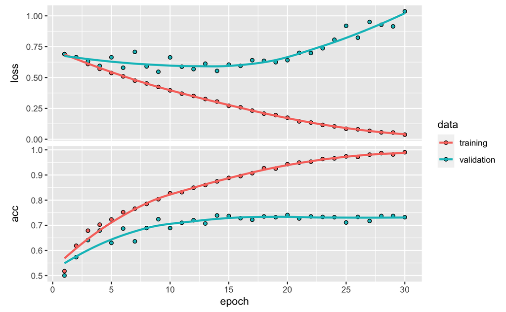

```r
plot(history)
```

Data augmentation ***

```r
datagen <- image_data_generator(
  rescale = 1/255,
  rotation_range = 40,
  width_shift_range = 0.2,
  height_shift_range = 0.2,
  shear_range = 0.2,
  zoom_range = 0.2,
  horizontal_flip = TRUE,
  fill_mode = "nearest"
)
```

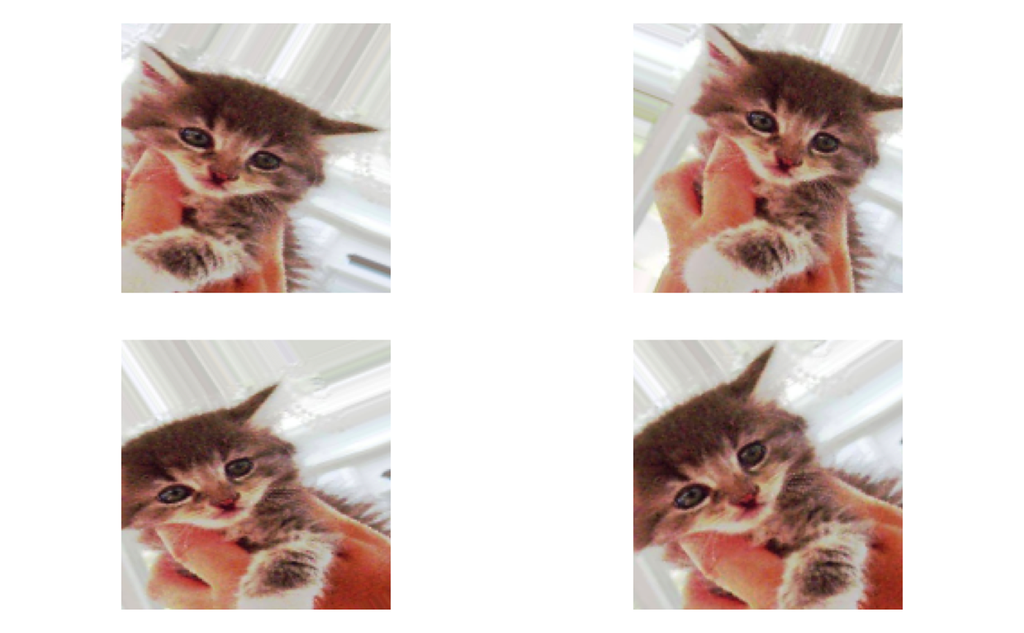

```r
fnames <- list.files(train_cats_dir, full.names = TRUE)
img_path <- fnames[[3]]
img <- image_load(img_path, target_size = c(150, 150))
img_array <- image_to_array(img)
img_array <- array_reshape(img_array, c(1, 150, 150, 3))
augmentation_generator <- flow_images_from_data(
  img_array,
  generator = datagen,
  batch_size = 1
)
op <- par(mfrow = c(2, 2), pty = "s", mar = c(1, 0, 1, 0))
for (i in 1:4) {
batch <- generator_next(augmentation_generator)
plot(as.raster(batch[1,,,])) }
par(op)
```